# Descriptive Stats

# 1 Number of Bank Branches

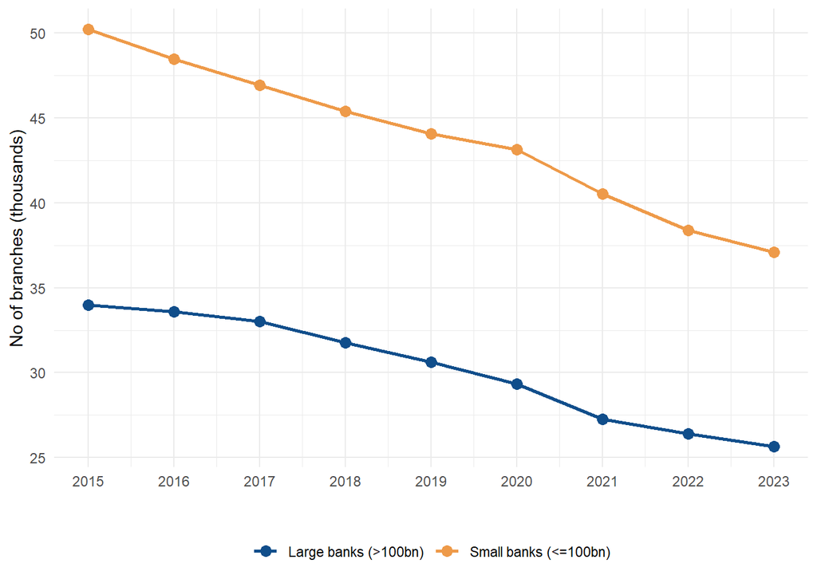

# 2 Percent of Branch Closures

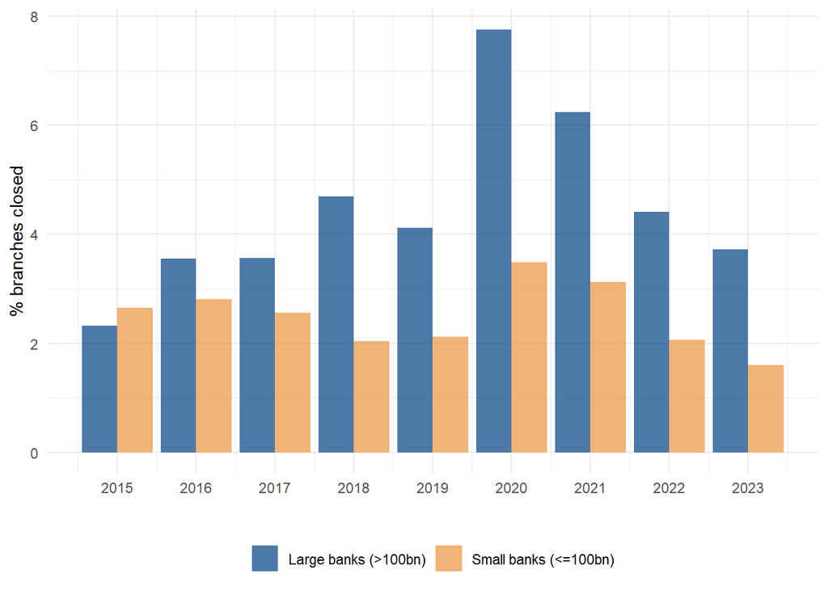

# 3 Closed vs. Operating branches comparison

This table presents summary statistics separately for closed vs operating branches separately for large banks (Panel A) and small banks (Panel B).

In each panel, the *first set of rows* show the descriptive statistics of branches that were still operating at the end of 2024 and *second set of rows* show the descriptive statistics of branches that were closed anytime between 2014 and 2023.

Newly added variables:

| Variable name | Description |
| --- | --- |
| merged_last_3_yrs | branch ownership changed in the last three years |
| same_zip_prior_3yr_branches | if merged_last_3yrs equals 1, whether acquiring bank had any branches in the same zip code prior to acquisition |
| est_df_factor_pooled_22_24 | Value generated by a $1 of deposits based on the 2022-2024 cycle |
| est_df_factor_pooled_16_19 | Value generated by a $1 of deposits based on the 2016-2019 cycle |
| pred_int_exp_chg_22_24 | Predicted branch-level change in interest rate expenditure based on the 2022-2024 first stage |
| pred_int_exp_chg_16_19 | Predicted branch-level change in interest rate expenditure based on the 2016-2019 first stage |
| bank_hhi | DSS measure of bank market power |
| bank_ruca | Mean Rural-Urban Commuting Area Codes (RUCA) of branches. 1=Core metro area, 10=Rural areas |

```
*Panel A: Large Banks*
```

```
|Variable                        |Obs  |Mean  |SD    |P10   |P25   |P50   |P75   |P90   |
|--------------------------------|-----|------|------|------|------|------|------|------|
|closed                          |   NA|    NA|    NA|    NA|    NA|    NA|    NA|    NA|
|merged_last_3_yrs               |25161|  0.08|  0.27|  0.00|  0.00|  0.00|  0.00|  0.00|
|same_zip_prior_3yr_branches     |25161|  0.01|  0.10|  0.00|  0.00|  0.00|  0.00|  0.00|
|no_branches_in_zipcode          |25161| 13.92|  8.35|  8.00| 10.00| 10.00| 20.00| 24.00|
|lag_county_deposit_hhi          |25161|  0.10|  0.12|  0.02|  0.03|  0.05|  0.12|  0.24|
|deposit_gr_3yrs                 |25161|135.68|147.05| 94.95|111.15|123.10|136.87|170.27|
|family_income                   |25161| 69.83| 38.74| 26.97| 43.31| 63.12| 90.16|121.96|
|college_pct                     |25161| 33.55| 19.64| 11.07| 18.39| 29.77| 46.06| 62.86|
|age                             |25161| 31.43| 11.73| 14.62| 24.38| 33.28| 39.93| 44.36|
|has_dividend_income_pct         |25161| 25.44| 14.05|  9.36| 14.64| 22.71| 33.99| 45.11|
|lag_hmda_mtg_amt_gr             |25161|-36.15| 10.43|-40.33|-40.33|-40.33|-35.53|-28.75|
|lag_county_gdp_gr               |25161|  2.04|  2.54| -0.80|  0.90|  2.10|  3.40|  5.30|
|lag_cra_loan_amount_amt_lt_1m_gr|25161|-20.73|  9.59|-28.13|-25.81|-22.30|-18.21|-11.35|
|establishments_gr               |25161|  0.02|  0.03| -0.02|  0.00|  0.02|  0.03|  0.06|
|payroll_gr                      |25161|  0.08|  0.09| -0.01|  0.04|  0.08|  0.13|  0.18|
|sophisticated                   |25161|  0.40|  0.49|  0.00|  0.00|  0.00|  1.00|  1.00|
|time_spent_min                  |25161| 19.25| 47.45|  2.50|  3.33|  5.08| 10.92| 43.33|
|distance_from_home_km           |25161|  7.77| 19.41|  3.40|  4.53|  6.31|  8.85| 12.07|
|bank_hhi                        |25161|  1.16|  0.36|  0.77|  0.90|  1.08|  1.53|  1.65|
|bank_ruca                       |25161|  1.47|  0.30|  1.10|  1.17|  1.45|  1.72|  1.93|
|pred_int_exp_chg_22_24          |25161|  1.40|  0.13|  1.23|  1.31|  1.40|  1.49|  1.57|
|pred_core_dep_chg_22_24         |25161| -3.19|  1.68| -5.54| -4.24| -2.94| -1.97| -1.31|
|est_df_factor_pooled_22_24      |25161|  0.21|  0.01|  0.20|  0.20|  0.21|  0.22|  0.22|
|pred_int_exp_chg_16_19          |25161|  0.67|  0.06|  0.59|  0.63|  0.67|  0.71|  0.75|
|pred_core_dep_chg_16_19         |25161| 60.27|  7.65| 50.62| 55.42| 61.13| 66.06| 69.59|
|est_df_factor_pooled_16_19      |25161|  0.20|  0.01|  0.19|  0.19|  0.20|  0.20|  0.21|
|closed                          |   NA|    NA|    NA|    NA|    NA|    NA|    NA|    NA|
|merged_last_3_yrs               |12006|  0.08|  0.27|  0.00|  0.00|  0.00|  0.00|  0.00|
|same_zip_prior_3yr_branches     |12006|  0.03|  0.18|  0.00|  0.00|  0.00|  0.00|  0.00|
|no_branches_in_zipcode          |12006| 12.77|  9.23|  3.00|  6.00| 10.00| 17.00| 25.00|
|lag_county_deposit_hhi          |12006|  0.09|  0.11|  0.02|  0.03|  0.05|  0.12|  0.21|
|deposit_gr_3yrs                 |12006|120.43|122.79| 90.39|101.09|111.96|125.20|144.19|
|family_income                   |12006| 68.07| 32.42| 35.15| 46.13| 61.39| 84.41|110.98|
|college_pct                     |12006| 37.31| 19.74| 14.83| 21.62| 33.59| 50.50| 66.53|
|age                             |12006| 37.45|  9.28| 26.89| 34.03| 38.67| 42.54| 46.32|
|has_dividend_income_pct         |12006| 24.03| 13.29|  9.30| 14.05| 21.26| 31.61| 42.53|
|lag_hmda_mtg_amt_gr             |12006| 16.14| 32.25|-30.67| -6.83| 16.37| 37.04| 66.02|
|lag_county_gdp_gr               |12006|  1.68|  3.98| -3.40| -0.50|  1.90|  4.10|  6.40|
|lag_cra_loan_amount_amt_lt_1m_gr|12006| 10.39| 32.65|-22.55| -6.19|  3.33| 10.69| 75.98|
|establishments_gr               |12006|  0.01|  0.03| -0.02| -0.01|  0.01|  0.03|  0.05|
|payroll_gr                      |12006|  0.05|  0.09| -0.04|  0.00|  0.04|  0.09|  0.14|
|sophisticated                   |12006|  0.41|  0.49|  0.00|  0.00|  0.00|  1.00|  1.00|
|time_spent_min                  |12006| 31.90| 65.68|  2.69|  3.83|  7.83| 21.88| 87.38|
|distance_from_home_km           |12006|  8.01|  6.47|  3.27|  4.43|  6.45|  9.54| 14.20|
|bank_hhi                        |12006|  1.17|  0.33|  0.83|  0.94|  1.09|  1.55|  1.68|
|bank_ruca                       |12006|  1.51|  0.42|  1.13|  1.19|  1.48|  1.71|  1.97|
|pred_int_exp_chg_22_24          |12006|  1.35|  0.15|  1.16|  1.25|  1.34|  1.45|  1.54|
|pred_core_dep_chg_22_24         |12006| -3.26|  1.60| -5.53| -4.26| -2.97| -2.06| -1.46|
|est_df_factor_pooled_22_24      |12006|  0.21|  0.01|  0.20|  0.20|  0.21|  0.22|  0.23|
|pred_int_exp_chg_16_19          |12006|  0.66|  0.07|  0.57|  0.61|  0.65|  0.70|  0.75|
|pred_core_dep_chg_16_19         |12006| 60.90|  6.47| 52.53| 56.19| 61.40| 66.13| 68.83|
|est_df_factor_pooled_16_19      |12006|  0.20|  0.01|  0.19|  0.20|  0.20|  0.21|  0.21|
```

```
*Panel B: Small Banks*
```

```
|Variable                        |Obs  |Mean   |SD       |P10   |P25   |P50   |P75   |P90   |
|--------------------------------|-----|-------|---------|------|------|------|------|------|
|closed                          |   NA|     NA|       NA|    NA|    NA|    NA|    NA|    NA|
|merged_last_3_yrs               |37919|   0.07|     0.26|  0.00|  0.00|  0.00|  0.00|  0.00|
|same_zip_prior_3yr_branches     |37919|   0.01|     0.07|  0.00|  0.00|  0.00|  0.00|  0.00|
|no_branches_in_zipcode          |37919|  12.14|     8.03|  5.00| 10.00| 10.00| 10.00| 20.00|
|lag_county_deposit_hhi          |37919|   0.14|     0.14|  0.03|  0.05|  0.10|  0.18|  0.29|
|deposit_gr_3yrs                 |37919| 131.74|   787.12| 95.70|107.65|119.38|133.63|154.67|
|family_income                   |37919|  58.49|    32.42| 19.42| 38.44| 55.93| 73.33| 97.53|
|college_pct                     |37919|  26.52|    17.10|  7.93| 14.86| 22.57| 34.64| 51.17|
|age                             |37919|  32.00|    12.98| 11.88| 23.72| 35.17| 41.60| 45.72|
|has_dividend_income_pct         |37919|  21.82|    11.55|  9.64| 13.65| 19.58| 27.17| 37.58|
|lag_hmda_mtg_amt_gr             |37919| -31.83|    14.61|-40.33|-40.33|-37.08|-29.21|-19.72|
|lag_county_gdp_gr               |37919|   1.18|     3.83| -3.10| -0.50|  1.50|  3.20|  5.30|
|lag_cra_loan_amount_amt_lt_1m_gr|37919| -15.26|    20.16|-30.33|-25.33|-20.03|-11.98|  4.33|
|establishments_gr               |37919|   0.02|     0.04| -0.03|  0.00|  0.02|  0.04|  0.06|
|payroll_gr                      |37919|   0.09|     0.10| -0.02|  0.03|  0.08|  0.13|  0.19|
|sophisticated                   |37919|   0.27|     0.44|  0.00|  0.00|  0.00|  1.00|  1.00|
|time_spent_min                  |37919|  47.94|    80.60|  2.67|  4.08| 12.33| 52.92|145.42|
|distance_from_home_km           |37919|  10.45|    34.72|  3.96|  5.69|  8.12| 11.22| 15.42|
|bank_hhi                        |37919|   0.66|     0.40|  0.31|  0.43|  0.56|  0.80|  1.12|
|bank_ruca                       |37919|   3.17|     2.22|  1.00|  1.47|  2.45|  4.25|  6.43|
|pred_int_exp_chg_22_24          |37919|   0.95|     0.23|  0.66|  0.78|  0.95|  1.12|  1.25|
|pred_core_dep_chg_22_24         |37919|  -2.15|     1.52| -4.17| -2.87| -1.93| -1.20| -0.56|
|est_df_factor_pooled_22_24      |37919|   0.25|     0.02|  0.22|  0.23|  0.25|  0.26|  0.27|
|pred_int_exp_chg_16_19          |37919|   0.50|     0.10|  0.38|  0.43|  0.50|  0.57|  0.63|
|pred_core_dep_chg_16_19         |37919|  29.48|    13.02| 12.87| 20.03| 29.41| 39.32| 46.91|
|est_df_factor_pooled_16_19      |37919|   0.20|     0.01|  0.19|  0.19|  0.20|  0.20|  0.20|
|closed                          |   NA|     NA|       NA|    NA|    NA|    NA|    NA|    NA|
|merged_last_3_yrs               | 9908|   0.17|     0.38|  0.00|  0.00|  0.00|  0.00|  1.00|
|same_zip_prior_3yr_branches     | 9908|   0.03|     0.17|  0.00|  0.00|  0.00|  0.00|  0.00|
|no_branches_in_zipcode          | 9908|   9.04|     8.00|  2.00|  3.00|  7.00| 12.00| 19.00|
|lag_county_deposit_hhi          | 9908|   0.10|     0.11|  0.02|  0.03|  0.07|  0.13|  0.22|
|deposit_gr_3yrs                 | 9908|1466.80|131329.41| 80.58| 93.91|106.38|123.39|149.79|
|family_income                   | 9908|  62.46|    28.09| 34.13| 44.07| 56.92| 75.87| 99.26|
|college_pct                     | 9908|  34.44|    18.79| 14.03| 19.75| 30.21| 46.51| 62.84|
|age                             | 9908|  37.81|     9.00| 27.90| 34.55| 38.98| 42.90| 46.37|
|has_dividend_income_pct         | 9908|  22.60|    12.04|  9.31| 14.02| 20.25| 29.08| 39.29|
|lag_hmda_mtg_amt_gr             | 9908|  13.96|    32.19|-31.61| -9.82| 15.07| 34.63| 63.44|
|lag_county_gdp_gr               | 9908|   1.38|     4.18| -4.20| -1.00|  1.70|  4.00|  6.30|
|lag_cra_loan_amount_amt_lt_1m_gr| 9908|  10.02|    31.14|-21.32| -5.81|  3.28| 12.17| 65.26|
|establishments_gr               | 9908|   0.01|     0.04| -0.03| -0.01|  0.01|  0.02|  0.05|
|payroll_gr                      | 9908|   0.05|     0.10| -0.04|  0.00|  0.04|  0.09|  0.15|
|sophisticated                   | 9908|   0.35|     0.48|  0.00|  0.00|  0.00|  1.00|  1.00|
|time_spent_min                  | 9908|  59.53|    90.32|  3.00|  4.98| 16.33| 73.25|197.47|
|distance_from_home_km           | 9908|  10.60|    14.41|  3.99|  5.67|  8.04| 11.65| 16.79|
|bank_hhi                        | 9908|   0.72|     0.44|  0.33|  0.45|  0.60|  0.86|  1.31|
|bank_ruca                       | 9908|   2.34|     1.54|  1.00|  1.18|  2.00|  2.86|  4.30|
|pred_int_exp_chg_22_24          | 9908|   0.97|     0.21|  0.70|  0.83|  0.98|  1.11|  1.23|
|pred_core_dep_chg_22_24         | 9908|  -2.62|     1.50| -4.76| -3.51| -2.33| -1.54| -0.96|
|est_df_factor_pooled_22_24      | 9908|   0.24|     0.02|  0.22|  0.23|  0.24|  0.26|  0.27|
|pred_int_exp_chg_16_19          | 9908|   0.51|     0.09|  0.39|  0.45|  0.51|  0.57|  0.63|
|pred_core_dep_chg_16_19         | 9908|  34.79|    11.08| 19.31| 27.14| 36.19| 43.59| 47.99|
|est_df_factor_pooled_16_19      | 9908|   0.20|     0.01|  0.19|  0.19|  0.20|  0.20|  0.21|
```

# 4 Bank-level beta, w, and customer characteristics

## 4.1 2022-2024 Sample

```
|Variable                |Obs |Mean |SD   |P10   |P25  |P50  |P75  |P90   |
|------------------------|----|-----|-----|------|-----|-----|-----|------|
|large_bank              |  NA|   NA|   NA|    NA|   NA|   NA|   NA|    NA|
|deposit_exp_deposits_chg|3593| 0.69| 0.39|  0.21| 0.38| 0.63| 0.95|  1.26|
|core_deposits_chg       |3593|-2.05| 6.01| -9.70|-6.20|-2.48| 1.47|  6.10|
|college_pct             |3593|28.62|12.66| 16.45|19.81|25.04|33.45| 46.47|
|has_dividend_income_pct |3593|20.26| 7.81| 11.22|14.78|19.89|24.40| 29.12|
|family_income           |3593|58.22|16.77| 40.61|47.39|55.20|65.60| 78.22|
|age                     |3593|40.94| 4.25| 35.80|38.32|40.85|43.35| 45.97|
|bank_hhi                |3593| 0.51| 0.38|  0.18| 0.26| 0.41| 0.63|  0.92|
|bank_ruca               |3593| 4.44| 2.91|  1.00| 1.67| 4.00| 7.00|  9.00|
|large_bank              |  NA|   NA|   NA|    NA|   NA|   NA|   NA|    NA|
|deposit_exp_deposits_chg|  22| 1.43| 0.60|  0.88| 1.05| 1.24| 1.91|  2.40|
|core_deposits_chg       |  22|-2.17|13.25|-14.06|-8.80|-7.38| 1.07| 14.73|
|college_pct             |  22|52.70|16.55| 38.98|44.21|48.57|58.60| 76.05|
|has_dividend_income_pct |  22|29.42| 9.92| 17.23|23.64|28.37|33.78| 40.15|
|family_income           |  22|82.27|34.24| 57.69|64.84|72.95|87.08|103.52|
|age                     |  22|37.55| 2.26| 34.45|36.44|38.00|39.03| 39.44|
|bank_hhi                |  22| 0.94| 0.47|  0.25| 0.68| 0.95| 1.21|  1.61|
|bank_ruca               |  22| 1.48| 0.48|  1.00| 1.04| 1.45| 1.73|  1.92|
```

## 4.2 2016-2019 Sample

```
|Variable                |Obs |Mean |SD   |P10  |P25  |P50  |P75  |P90   |
|------------------------|----|-----|-----|-----|-----|-----|-----|------|
|large_bank              |  NA|   NA|   NA|   NA|   NA|   NA|   NA|    NA|
|deposit_exp_deposits_chg|4064| 0.41| 0.25| 0.09| 0.21| 0.38| 0.58|  0.78|
|core_deposits_chg       |4064|18.62|21.37|-3.78| 2.85|13.33|29.23| 49.65|
|college_pct             |4064|29.73|13.74|16.56|20.14|25.77|35.35| 48.93|
|has_dividend_income_pct |4064|20.58| 8.44|11.03|14.67|20.03|24.79| 30.14|
|family_income           |4064|59.66|18.39|40.78|47.67|56.03|67.49| 82.74|
|age                     |4064|40.81| 4.32|35.76|38.16|40.68|43.20| 45.76|
|bank_hhi                |4064| 0.49| 0.38| 0.17| 0.26| 0.40| 0.61|  0.90|
|bank_ruca               |4064| 4.21| 2.90| 1.00| 1.47| 4.00| 6.60|  8.71|
|large_bank              |  NA|   NA|   NA|   NA|   NA|   NA|   NA|    NA|
|deposit_exp_deposits_chg|  27| 0.63| 0.24| 0.39| 0.48| 0.54| 0.73|  0.98|
|core_deposits_chg       |  27|28.77|32.78|-3.12|10.88|17.13|54.08| 83.46|
|college_pct             |  27|54.75|16.07|40.78|44.93|53.86|62.53| 77.37|
|has_dividend_income_pct |  27|30.85|11.68|18.38|24.13|28.99|35.57| 43.97|
|family_income           |  27|85.38|33.07|60.66|66.70|72.96|95.37|115.97|
|age                     |  27|37.88| 2.78|34.35|36.52|38.07|39.12| 41.07|
|bank_hhi                |  27| 0.90| 0.45| 0.22| 0.64| 0.93| 1.08|  1.58|
|bank_ruca               |  27| 1.41| 0.46| 1.00| 1.01| 1.24| 1.60|  1.90|
```

# 5 Prediction Regression

This table shows the bank-level regression results that is used to predict branch level w and beta.

## 5.1 2022-2024 rate cycle

```
============================================================================
                                            Dependent variable:
                                --------------------------------------------
                                deposit_exp_deposits_chg~ core_deposits_chg~
                                           (1)                   (2)
----------------------------------------------------------------------------
age                                     -0.007***               0.0003
                                         (0.002)               (0.028)
log(family_income)                       -0.067*                -0.559
                                         (0.038)               (0.632)
has_dividend_income_pct                   0.001                -0.055**
                                         (0.001)               (0.024)
college_pct                             0.006***               -0.036**
                                         (0.001)               (0.015)
bank_hhi                                -0.134***               -0.138
                                         (0.017)               (0.285)
log(bank_assets)                        0.091***                -0.074
                                         (0.005)               (0.087)
bank_ruca                               0.011***                -0.001
                                         (0.003)               (0.045)
Constant                                 -0.044                 3.346
                                         (0.171)               (2.817)
----------------------------------------------------------------------------
Observations                              3,615                 3,615
R2                                        0.161                 0.027
Adjusted R2                               0.160                 0.025
Residual Std. Error (df = 3607)           0.364                 5.997
F Statistic (df = 7; 3607)              99.065***             14.120***
============================================================================
Note:                                            *p<0.1; **p<0.05; ***p<0.01
```

## 5.2 2016-2019 rate cycle.

```
============================================================================
                                            Dependent variable:
                                --------------------------------------------
                                deposit_exp_deposits_chg~ core_deposits_chg~
                                           (1)                   (2)
----------------------------------------------------------------------------
age                                     -0.002**               0.194**
                                         (0.001)               (0.082)
log(family_income)                      -0.054**                2.656
                                         (0.023)               (1.856)
has_dividend_income_pct                  -0.0002              -0.234***
                                         (0.001)               (0.067)
college_pct                             0.004***               0.165***
                                         (0.001)               (0.045)
bank_hhi                                -0.085***             -4.853***
                                         (0.011)               (0.845)
log(bank_assets)                        0.039***               5.766***
                                         (0.003)               (0.256)
bank_ruca                               0.011***              -0.450***
                                         (0.002)               (0.136)
Constant                                  0.118               -68.071***
                                         (0.104)               (8.278)
----------------------------------------------------------------------------
Observations                              4,091                 4,091
R2                                        0.088                 0.186
Adjusted R2                               0.087                 0.185
Residual Std. Error (df = 4083)           0.243                 19.390
F Statistic (df = 7; 4083)              56.428***             133.358***
============================================================================
Note:                                            *p<0.1; **p<0.05; ***p<0.01
```

## 5.3 Univariate 2022-2024 Cycle

### 5.3.1 deposit_exp_deposits_chg

```
===========================================================================
                                            Dependent variable:
                                -------------------------------------------
                                         deposit_exp_deposits_chg~
                                   (1)        (2)        (3)        (4)
---------------------------------------------------------------------------
age                             -0.006***
                                 (0.002)
log(family_income)                          0.122***
                                            (0.026)
has_dividend_income_pct                                0.005***
                                                       (0.001)
college_pct                                                       0.005***
                                                                  (0.001)
bank_hhi                        -0.153***  -0.144***  -0.145***  -0.138***
                                 (0.017)    (0.017)    (0.017)    (0.017)
log(bank_assets)                 0.106***   0.104***   0.103***   0.094***
                                 (0.005)    (0.005)    (0.005)    (0.005)
bank_ruca                         0.002      0.003      0.0002    0.008***
                                 (0.002)    (0.002)    (0.002)    (0.002)
Constant                        -0.313***  -1.040***  -0.611***  -0.605***
                                 (0.094)    (0.118)    (0.067)    (0.066)
---------------------------------------------------------------------------
Observations                      3,615      3,615      3,615      3,615
R2                                0.137      0.139      0.141      0.155
Adjusted R2                       0.136      0.138      0.140      0.154
Residual Std. Error (df = 3610)   0.369      0.369      0.368      0.365
F Statistic (df = 4; 3610)      143.513*** 145.263*** 147.841*** 165.396***
===========================================================================
Note:                                           *p<0.1; **p<0.05; ***p<0.01
```

### 5.3.2 core_deposits_chg

```
=======================================================================
                                          Dependent variable:
                                ---------------------------------------
                                          core_deposits_chg~
                                   (1)       (2)       (3)       (4)
-----------------------------------------------------------------------
age                              -0.049*
                                 (0.025)
log(family_income)                        -2.904***
                                           (0.422)
has_dividend_income_pct                             -0.105***
                                                     (0.013)
college_pct                                                   -0.074***
                                                               (0.009)
bank_hhi                          0.248    -0.109    -0.085    -0.061
                                 (0.282)   (0.284)   (0.282)   (0.281)
log(bank_assets)                -0.275***  -0.155*   -0.128    -0.062
                                 (0.084)   (0.084)   (0.084)   (0.087)
bank_ruca                       0.112***   -0.001    0.066*    -0.034
                                 (0.039)   (0.040)   (0.038)   (0.041)
Constant                         2.780*   11.652***   1.441     1.027
                                 (1.537)   (1.929)   (1.085)   (1.082)
-----------------------------------------------------------------------
Observations                      3,615     3,615     3,615     3,615
R2                                0.008     0.020     0.024     0.024
Adjusted R2                       0.007     0.019     0.023     0.023
Residual Std. Error (df = 3610)   6.052     6.016     6.002     6.004
F Statistic (df = 4; 3610)      7.407***  18.364*** 22.474*** 21.969***
=======================================================================
Note:                                       *p<0.1; **p<0.05; ***p<0.01
```

## 5.4 Univariate 2016-2019 Cycle

### 5.4.1 deposit_exp_deposits_chg

```
=======================================================================
                                          Dependent variable:
                                ---------------------------------------
                                       deposit_exp_deposits_chg~
                                   (1)       (2)       (3)       (4)
-----------------------------------------------------------------------
age                             -0.002**
                                 (0.001)
log(family_income)                        0.066***
                                           (0.015)
has_dividend_income_pct                             0.003***
                                                    (0.0005)
college_pct                                                   0.003***
                                                              (0.0003)
bank_hhi                        -0.096*** -0.090*** -0.089*** -0.083***
                                 (0.011)   (0.011)   (0.011)   (0.011)
log(bank_assets)                0.048***  0.047***  0.045***  0.040***
                                 (0.003)   (0.003)   (0.003)   (0.003)
bank_ruca                       0.005***  0.007***  0.005***  0.010***
                                 (0.002)   (0.002)   (0.001)   (0.002)
Constant                         -0.086   -0.422*** -0.187*** -0.183***
                                 (0.056)   (0.071)   (0.040)   (0.040)
-----------------------------------------------------------------------
Observations                      4,091     4,091     4,091     4,091
R2                                0.067     0.070     0.072     0.085
Adjusted R2                       0.066     0.069     0.071     0.084
Residual Std. Error (df = 4086)   0.245     0.245     0.245     0.243
F Statistic (df = 4; 4086)      73.107*** 76.686*** 79.571*** 94.500***
=======================================================================
Note:                                       *p<0.1; **p<0.05; ***p<0.01
```

### 5.4.2 core_deposits_chg

```
===========================================================================
                                            Dependent variable:
                                -------------------------------------------
                                            core_deposits_chg~
                                   (1)        (2)        (3)        (4)
---------------------------------------------------------------------------
age                               0.105
                                 (0.075)
log(family_income)                          3.063**
                                            (1.227)
has_dividend_income_pct                                 0.030
                                                       (0.038)
college_pct                                                       0.086***
                                                                  (0.027)
bank_hhi                        -5.080***  -4.690***  -4.935***  -4.645***
                                 (0.832)    (0.843)    (0.841)    (0.840)
log(bank_assets)                 5.989***   5.854***   5.923***   5.716***
                                 (0.244)    (0.248)    (0.249)    (0.255)
bank_ruca                       -0.741***  -0.585***  -0.685***  -0.530***
                                 (0.119)    (0.123)    (0.115)    (0.125)
Constant                        -55.044*** -62.336*** -50.874*** -51.030***
                                 (4.440)    (5.646)    (3.192)    (3.182)
---------------------------------------------------------------------------
Observations                      4,091      4,091      4,091      4,091
R2                                0.182      0.183      0.181      0.183
Adjusted R2                       0.181      0.182      0.181      0.183
Residual Std. Error (df = 4086)   19.435     19.425     19.438     19.415
F Statistic (df = 4; 4086)      226.811*** 228.111*** 226.405*** 229.386***
===========================================================================
Note:                                           *p<0.1; **p<0.05; ***p<0.01
```

# 6 Branch-level deposit franchise value estimate

This section provides summary statistics of the branch-level estimate of the deposit franchise factor, estimated based on 22-24 cycle and 16-19 cycle.

## 6.1 2022-2024 Cycle

```
Mean of DF Factor: 0.231
```

```
SD  of DF Factor: 0.024
```

```
|Variable                  |Obs  |Mean |SD  |P10  |P25  |P50  |P75  |P90  |
|--------------------------|-----|-----|----|-----|-----|-----|-----|-----|
|large_bank                |   NA|   NA|  NA|   NA|   NA|   NA|   NA|   NA|
|est_df_factor_pooled_22_24|26412| 0.21|0.01| 0.19| 0.20| 0.21| 0.22| 0.22|
|pred_int_exp_chg_22_24    |26412| 1.40|0.14| 1.22| 1.31| 1.40| 1.50| 1.57|
|pred_core_dep_chg_22_24   |26412|-3.14|1.69|-5.49|-4.19|-2.89|-1.91|-1.24|
|large_bank                |   NA|   NA|  NA|   NA|   NA|   NA|   NA|   NA|
|est_df_factor_pooled_22_24|38374| 0.25|0.02| 0.22| 0.23| 0.25| 0.26| 0.27|
|pred_int_exp_chg_22_24    |38374| 0.96|0.23| 0.66| 0.79| 0.96| 1.13| 1.25|
|pred_core_dep_chg_22_24   |38374|-2.10|1.52|-4.13|-2.83|-1.87|-1.15|-0.51|
```

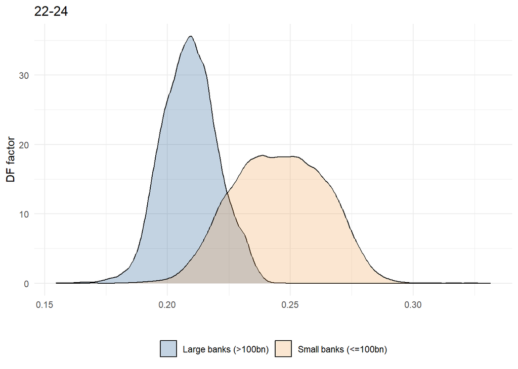

## 6.2 2016-2019 Cycle

```
Mean of DF Factor: 0.2
```

```
SD of DF Factor: 0.006
```

```
|Variable                  |Obs  |Mean |SD   |P10  |P25  |P50  |P75  |P90  |
|--------------------------|-----|-----|-----|-----|-----|-----|-----|-----|
|large_bank                |   NA|   NA|   NA|   NA|   NA|   NA|   NA|   NA|
|est_df_factor_pooled_16_19|30607| 0.20| 0.01| 0.19| 0.20| 0.20| 0.21| 0.21|
|pred_int_exp_chg_16_19    |30607| 0.66| 0.07| 0.58| 0.61| 0.65| 0.71| 0.76|
|pred_core_dep_chg_16_19   |30607|62.33| 5.97|53.78|57.16|62.89|67.71|69.52|
|large_bank                |   NA|   NA|   NA|   NA|   NA|   NA|   NA|   NA|
|est_df_factor_pooled_16_19|44087| 0.20| 0.01| 0.19| 0.20| 0.20| 0.20| 0.21|
|pred_int_exp_chg_16_19    |44087| 0.48| 0.10| 0.36| 0.41| 0.48| 0.55| 0.61|
|pred_core_dep_chg_16_19   |44087|31.58|12.34|15.16|21.78|31.56|41.93|48.11|
```

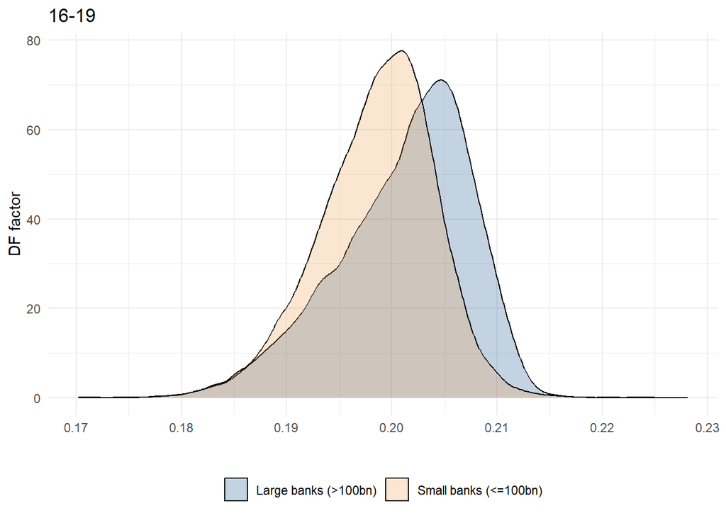

# 7 22-24 vs. 16-19

This section compares the df factor estimates, predicted interest expense changes, and core deposit changes in the two cycles.

## 7.1 DF Factor

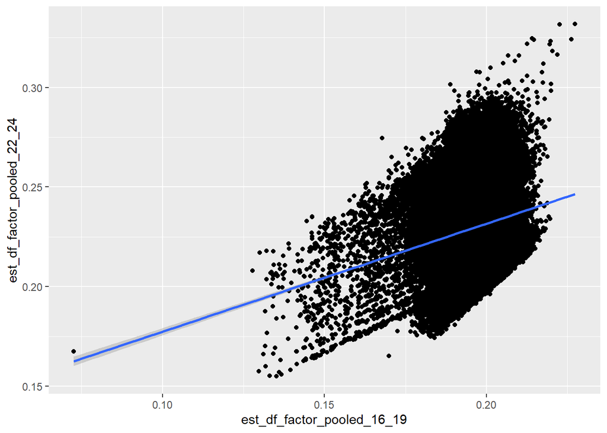

## 7.2 Interest Expenditure

Strongly positively correlated in the two cycles.

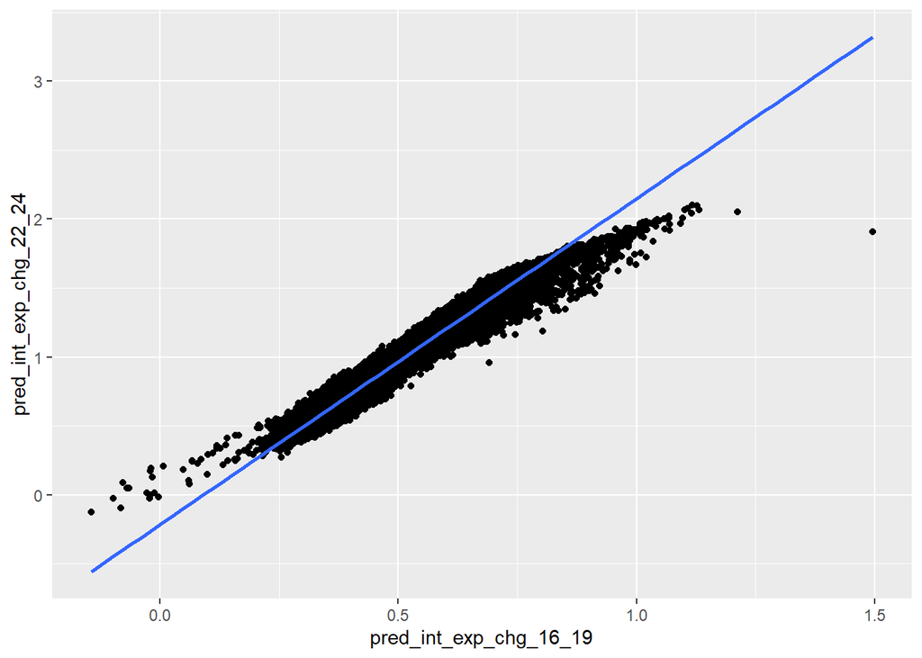

## 7.3 Change in core deposits

> **Q: Should we only use change in interest expenditure estimate in the closure models?**

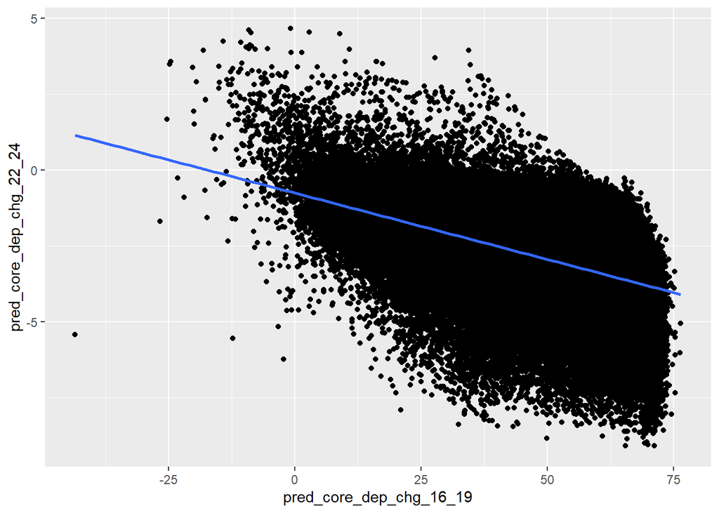

# 8 Geographic distribution

This table provides summary statistics on number of counties and number of states banks in large and small sample operate.

```
|Variable   |Obs |Mean  |SD    |P10|P25 |P50  |P75   |P90  |
|-----------|----|------|------|---|----|-----|------|-----|
|large_bank |  NA|    NA|    NA|NA |  NA|   NA|    NA|   NA|
|no_counties|6614|  3.84| 10.54| 1 |1.00|  2.0|  3.00|  6.0|
|no_states  |6614|  1.22|  0.95| 1 |1.00|  1.0|  1.00|  2.0|
|large_bank |  NA|    NA|    NA|NA |  NA|   NA|    NA|   NA|
|no_counties|  30|202.50|238.37| 1 |4.50|138.5|265.75|543.6|
|no_states  |  30| 12.57| 10.16| 1 |3.25| 12.0| 16.00| 26.2|
```